# Modulo Machine Learning con R - Master UCM: Big Data, Data Science

Miguel Moreno

19/04/2022

## Introducción

En este documento tratamos algunos de los aspectos fundamentales que hemos desarrollado durante el módulo de Machine Learning en R para el concurso de datos Pump It Up: Mining the water table. Concretamente este concurso trata de establecer la mejor clasificación del tipo de bombas de agua en base a un conjunto de variables. Para ello se permite realizar cualquier modificación necesaria sobre el dataset, análisis previo, empleo de distintos algoritmos para así encontrar el mejor scoring (puntuación) de dicha clasificación.

## Resumen del proceso

Se ha utilizado el esquema planteado en clase a lo largo del módulo para realizar este documento. Utilizando en primer lugar una depuración de los datos categóricos mediante transformaciones sobre strings en algunas de las variables. A continuación, realizamos varias pruebas aumentando o disminuyendo la cantidad de variables utilizadas para confeccionar el dataset final y utilizando la clasificación mediante arboles aleatorios.

En base a las distintas puntuaciones obtenidas en local o en la plataforma seguimos variando la confección pero manteniendo siempre este método de clasificación, ya que mediante XGBoost, GBM o ensamblado de modelos la puntuación en la plataforma se ve reducida (debido quizás a un overfitting del modelo generado). Se exponen en este trabajo un total de tres modificaciones, sin embargo se han llegado a realizar mas de 6 modificaciones mediante distintos algoritmos, obteniendo en todas ellas una puntuación menor a la conseguida al final del documento.

## Obtención de los datos

Los datos han sido descargados a través de la web Driven Data, donde podemos practicar e incluso participar en competiciones con distintos tipos de datos. Por lo que descargamos los datasets de la competición los cuales están divididos en Training, Test y valor de la Variable a predecir. Se hace uso de distintos paquetes de librerías usados a lo largo del módulo de Data Mining o Machine Learning en R. De igual manera, usamos algunas funciones proporcionadas en el módulo de Data Mining para optimizar los resultados.

```r
#Importamos los datasets asociados al test, training y dependiente
datTestOri <- read.csv('pumpDataTest.csv')
datTrainOri <- read.csv('pumpDataTrain.csv')
datTrainLabOri <- read.csv('pumpTrainLabels.csv')
```

## Inspección de los datos

Realizamos una inspección de los datos de Train para poder obtener una visión de las variables:

```
## 'data.frame':    59400 obs. of  40 variables:
##  $ id                   : int  69572 8776 34310 67743 19728 9944 19816 54551 53934 46144 ...
##  $ amount_tsh           : num  6000 0 25 0 0 20 0 0 0 0 ...
##  $ date_recorded        : chr  "2011-03-14" "2013-03-06" "2013-02-25" "2013-01-28" ...
##  $ funder               : chr  "Roman" "Grumeti" "Lottery Club" "Unicef" ...
##  $ gps_height           : int  1390 1399 686 263 0 0 0 0 0 0 ...
##  $ installer            : chr  "Roman" "GRUMETI" "World vision" "UNICEF" ...
##  $ longitude            : num  34.9 34.7 37.5 38.5 31.1 ...
##  $ latitude             : num  -9.86 -2.15 -3.82 -11.16 -1.83 ...
##  $ wpt_name             : chr  "none" "Zahanati" "Kwa Mahundi" "Zahanati Ya Nanyumbu" ...
##  $ num_private          : int  0 0 0 0 0 0 0 0 0 0 ...
##  $ basin                : chr  "Lake Nyasa" "Lake Victoria" "Pangani" "Ruvuma / Southern Coast" ...
##  $ subvillage           : chr  "Mnyusi B" "Nyamara" "Majengo" "Mahakamani" ...
##  $ region               : chr  "Iringa" "Mara" "Manyara" "Mtwara" ...
##  $ region_code          : int  11 20 21 90 18 4 17 17 14 18 ...
```

[output cut: 26 more lines]

```
## [1] 0
```

Como observamos, el número de NA’s obtenido es 0, lo que alivia nuestro trabajo en gran medida. Por otra parte, no hemos obtenido variables mal codificadas, por lo que quizás a lo sumo haya que realizar pequeñas conversiones sobre algunas columnas.

## Pasos previos

Aplicamos algunas operaciones a las variables del dataset. Ya sea debido a la duplicidad de columnas, valores muy similares en ellas, tipos de variables erróneos… No existe un criterio único para operar, las transformaciones son a gusto del desarrollador.

En primer lugar comenzamos con las variables categóricas observando el número de niveles de cada una de ellas y escogiendo aquellas que no superen los 2.500 niveles.

```r
#Analizamos las columnas categoricas
datCates <- rbind(datTrainOri, datTestOri) %>%
  select.(where(is.character)) %>%
  mutate.(across.(where(is.character), ~ length(unique(.)))) %>%
  distinct.() %>%
  t() %>%
  as.data.frame() %>%
  rownames_to_column(var = "variables") %>%
  rename.(niveles = V1) %>%
  arrange.(niveles) %>%
  as.data.table()

#Unimos ambos datasetes train y test para aplicar los cambios
datModel <- rbind(datTrainOri, datTestOri)

#Seleccionamos las columnas filtrando el numero de niveles en 2.500
cols_god <- datCates %>%
  filter.(niveles <= 2500 & niveles > 1) %>%
  select.(variables) %>%
  pull.()

#Seleccionamos aquellas con esa cantidad de niveles
datModel %<>%
  select.(where(is.numeric) | where(is.logical) | all_of(cols_god)) %>%
  mutate.(across.(where(is.logical), ~ as.numeric(.))) %>%
  as.data.frame()

datCates
```

```
##                 variables niveles
##  1:           recorded_by       1
##  2:        public_meeting       3
##  3:                permit       3
##  4:          source_class       3
##  5:      management_group       5
##  6:              quantity       5
##  7:        quantity_group       5
##  8:         quality_group       6
##  9: waterpoint_type_group       6
## 10: extraction_type_class       7
## 11:               payment       7
## 12:          payment_type       7
## 13:           source_type       7
## 14:       waterpoint_type       7
```

[output cut: 17 more lines]

Ahora disponemos de un dataset llamado datModel() donde tenemos todos los valores del Training y Test con un total de 36 variables. Comenzamos a realizar modificaciones en aquellas que consideremos.

## Análisis de columnas categóricas

Establecemos unos criterios generales en todas las variables de este tipo tales como: uso de minúsculas para agrupar posibles valores que pudieran diferir, cambio de todos aquellos campos vacíos ” “, valores con categoría”not known” o incluso caracteres no cualitativos como son “0” o “-”, todos ellos bajo un mismo valor nuevo “unknown”.

```r
#Minusculas y valores inconclusos a unknown
datModel %<>%
  mutate.(across.(where(is.character), ~ tolower(.))) %>%
  mutate.(across.(where(is.character), ~ replace(. , . == "", "unknown"))) %>%
  mutate.(across.(where(is.character), ~ replace(. , . == "not known", "unknown"))) %>%
  mutate.(across.(where(is.character), ~ replace(. , . == "0", "unknown"))) %>%
  mutate.(across.(where(is.character), ~ replace(. , . == "-", "unknown")))
```

Hemos comprobado que podemos realizar pequeñas modificaciones a variables de tipo String en las columnas categóricas. Aplicamos un criterio similar para algunas de las columnas categóricas restantes modificando ciertos aspectos de su cadena de caracteres.

```r
#Visualizacion de strings similares mediante paquete stringr, tambien es valido str_detect
unique(str_subset(datModel$funder,"^gove"))
```

```
##  [1] "government of tanzania"   "government/ community"
##  [3] "government /tassaf"       "government/ world bank"
##  [5] "government"               "government /sda"
##  [7] "government and community" "government of misri"
##  [9] "government/tassaf"        "government/school"
## [11] "government/tcrs"          "government /world vision"
## [13] "government/julius"
```

```r
unique(str_subset(datModel$installer,"^gove"))
```

```
##  [1] "government"               "gove"
##  [3] "gover"                    "governme"
##  [5] "government /tcrs"         "government /community"
##  [7] "goverm"                   "govern"
##  [9] "government /sda"          "government and community"
## [11] "government of misri"      "governmen"
## [13] "government/tcrs"          "government /world vision"
```

```r
#Bucle que recorre posibles valores similares y los unifica
for (i in c("gove","gover","govern","governme","goverm","governmen")) {
  y2 <- datModel$installer == i
  datModel$installer[y2] <- "government"
}

#Transformamos mas caracteres que puedan generar solapacion entre categorias
datModel %<>%
  mutate.(across.(where(is.character), ~ stri_replace_all_fixed(. , " ", ""))) %>%
  mutate.(across.(where(is.character), ~ stri_replace_all_fixed(. , c(".","-","_","&","/","(",")"), "", vectorize_all = FALSE))) %>%
  mutate.(across.(where(is.character), ~ stri_replace_all_fixed(. , " ", "")))
```

Continuamos revisando las columnas categóricas sin adentrarnos en las numéricas. Podemos observar que el número de apariciones en las variables region y region_code es distinto, sin mucho sentido, podríamos aplicar un drop de la variable region y reservar unicamente su tipo numérico (region_code). Así mismo, hemos encontrado algunas variables que comparten valores muy similares o incluso llegan a estar duplicadas.

Procederemos a eliminarlas, reduciendo así el número de variabes del dataset.

```r
#Eliminamos aquellas columnas "duplicadas"
datModel$quantity_group <- NULL
datModel$waterpoint_type_group <- NULL
datModel$payment_type <- NULL
```

## Análisis de columnas numéricas

A continuación realizamos una evaluación similar para este tipo de variables. Imputación sobre los valores atípicos, reescalado de valores numéricos, paso a valores logarítmicos para normalizar distrbuciones… son algunas de las modificaciones que se suelen realizar en el proceso de minado de datos.

¿Existe alguna columna que posea valores atípicos?. Mediante un diagrama de cajas y bigotes podemos hacernos una idea de como está la situación.

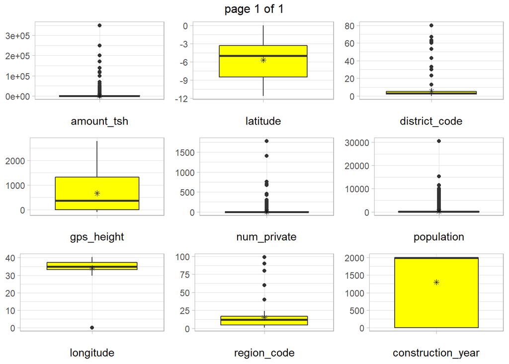

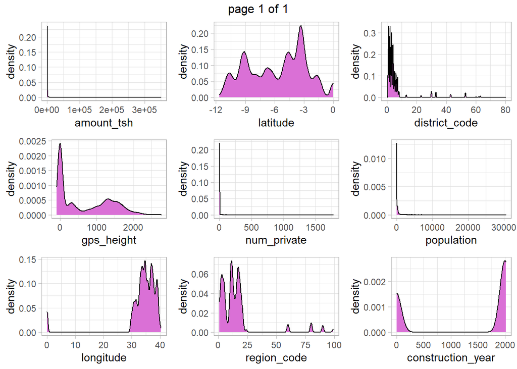

Además, es un dataset conformado mayoritariamente por variables categóricas, por lo que optamos por no tratar estos outliers para no variar mucho sus distribuciones.

## Aplicación del modelo

Una vez aplicadas todas las transformaciones sobre datModel debemos separar los datos de nuevo en dos datasets distintos para realizar nuestra parte de entrenamiento del modelo y aplicar las predicciones sobre la parte de test.

```r
#Volvemos a generar el dataset de train
datTrain <- datModel %>%
            filter.(datModel$id == datTrainOri$id) %>%
            mutate.(status_group = as.factor(datTrainLabOri$status_group)) %>%
            as.data.frame()

#Volvemos a generar el sataset de test
datTest <- datModel %>%
            filter.(datModel$id == datTestOri$id) %>%
            as.data.frame()
```

Utilizamos como hemos comentado al inicio, un modelo basado en Random Forest sobre el dataset de train para entrenar el modelo.

```r
#Creacion del modelo
mitrain <- copy(datTrain)
mymodel <- ranger(
  status_group ~. ,
  data = mitrain,
  importance = 'impurity',
  num.trees  = 550,
  mtry       = 6
)
```

Medimos la precisión del modelo generado y establecemos un nuevo objeto que mide la importancia de las variables.

```r
#Evaluamos la precision del modelo
accu_val <- 1 - mymodel$prediction.error
accu_val
```

```
## [1] 0.817963
```

```r
#Tabla de variables e importancia
varImp <- mymodel$variable.importance %>%
  as.data.frame() %>%
  rownames_to_column(var = "variables") %>%
  rename.(importancia = 2) %>%
  arrange.(-importancia) %>%
  as.data.table()
```

Generamos una representación del modelo mediante el uso de la librería ggplot():

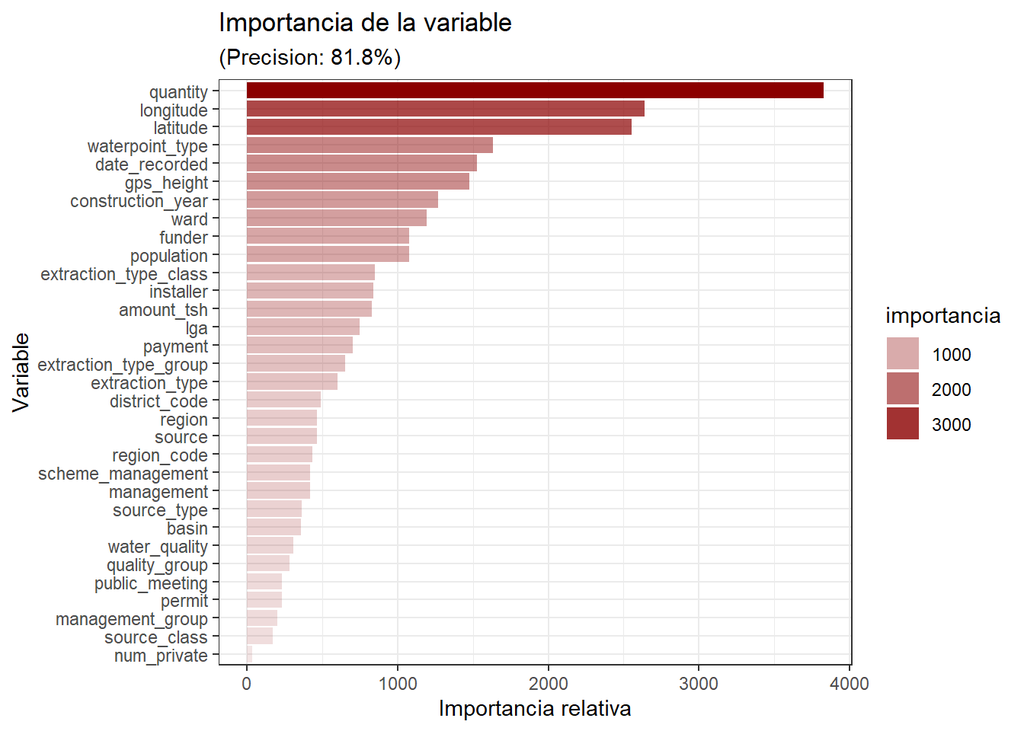

```r
#Creacion del grafico
ggplot(varImp[-4,], aes(fct_reorder(variables, importancia), importancia, alpha = importancia)) +
  geom_col(group = 1, fill = "darkred") +
  coord_flip() +
  labs(
    title = "Importancia de la variable",
    subtitle = paste("(Precision: ", round(accu_val*100,2), "%)", sep = ""),
    x = "Variable",
    y = "Importancia relativa"
  ) +
  theme_bw()
```

## Predicción del modelo

Como último paso, realizamos la predicción de la funcionalidad de las bombas de agua sobre los datos de test. Tras esto, subiremos los resultados a la competición en Data Driven para comprobar como de positiva ha sido la clasificación.

```r
#Creamos la prediccion
pred <- predict(mymodel, datTest)$predictions

#Objeto generado con el Id y el Valor de la bomba
tosubmit <- data.frame(id = datTest$id, status_group = pred)

#Generamos el csv con el formato adecuado para la plataforma
fwrite(
  tosubmit,
  paste("C:/Users/Miguel/Documents/MASTER BIG DATA UCM/Modulos/9 - Machine learning R-Python/Machine learning con R/mlTry1_", ncol(datModel), "_acc_", floor(accu_val*10000), ".csv", sep = "")
)
```

El valor obtenido no ha sido del todo negativo, a partir de este punto se realizan las mejoras sobre el proceso anterior. Manteniendo algunos aspectos y cambiando otros.

## Mejora del modelo

Volvemos a repetir los pasos realizados anteriormente y partimos del dataset datModel(). En esta mejora número 2, trataremos de recoger aquellas variables que poseen una cantidad menor o igual a 1.000 niveles.

```r
#Unimos ambos datasetes train y test para aplicar los cambios despues de ejecutar enetregaMachLearn
datModel <- rbind(datTrainOri, datTestOri)

#Seleccionamos las columnas filtrando el numero de niveles en 1000
cols_god <- datCates %>%
  filter.(niveles <= 1000 & niveles > 1) %>%
  select.(variables) %>%
  pull.()

cols_god
```

```
##  [1] "public_meeting"        "permit"                "source_class"
##  [4] "management_group"      "quantity"              "quantity_group"
##  [7] "quality_group"         "waterpoint_type_group" "extraction_type_class"
## [10] "payment"               "payment_type"          "source_type"
## [13] "waterpoint_type"       "water_quality"         "basin"
## [16] "source"                "management"            "scheme_management"
## [19] "extraction_type_group" "extraction_type"       "region"
## [22] "lga"                   "date_recorded"
```

```r
#Seleccionamos aquellas con esa cantidad de niveles
datModel %<>%
  select.(where(is.numeric) | where(is.logical) | all_of(cols_god)) %>%
  mutate.(across.(where(is.logical), ~ as.numeric(.))) %>%
  as.data.frame()
```

De igual manera, se aplican las modificaciones de tipo String como anteriormente se ha realizado (líneas 127 - 154 de código).

El modelo de clasificación ejecutado vuelve a ser del tipo Random Forest, aumentando el número de árboles a 600 y manteniendo el mtry = 6. Nuestro valor de precisión del modelo en local ha sido de:

```r
#Creacion del modelo
mitrain <- copy(datTrain)
set.seed(1234)
mymodel <- ranger(
  status_group ~. ,
  data = mitrain,
  importance = 'impurity',
  num.trees  = 600,
  mtry  = 6
)

#Evaluamos la precision del modelo
accu_val <- 1 - mymodel$prediction.error
accu_val
```

```
## [1] 0.8158586
```

```r
#Creamos la prediccion
pred <- predict(mymodel, datTest)$predictions
```

## Nueva mejora sobre el modelo

Revertimos la situación de las variables escogidas para conformar nuestro dataset. Esta vez, escogeremos aquellas que posean una cantidad menor o igual a 3.000 niveles. Reduciremos esta cantidad mediante una fase de lumping.

```r
#Unimos ambos datasetes train y test para aplicar los cambios
datModel <- rbind(datTrainOri, datTestOri)

#Seleccionamos las columnas filtrando el numero de niveles en 2.500
cols_god <- datCates %>%
  filter.(niveles <= 3000 & niveles > 1) %>%
  select.(variables) %>%
  pull.()
```

Añadimos esta vez una imputación previa de todos los valores vacíos.

```r
#Imputacion de NA's con RandomForest
datModel <- missRanger(datModel, pmm.k = 3, num.trees = 200)
```

```
##
## Missing value imputation by random forests
##
##   Variables to impute:
```

A partir de aquí, realizamos de nuevo las mismas modificaciones que en los dos casos anteriores, modificación de strings extraños en el dataset, eliminación de columnas duplicadas..

Introducimos la nueva modificación antes mencionada, una fase de lumping para categorizar como ‘other’ a todos los valores que excepto a los n más frecuentes. El valor de n se ha decidido en base a la distribución de los niveles en estas columnas. Nos dimos cuenta que pese a reducir el número de niveles en scheme_name, su valor más representativo sería ‘unknown’, por lo que la eliminamos finalmente.

```r
#Fase de lumping
datModel %<>%
  mutate.(ward = fct_lump_n(ward, n = 380, other_level = 'other')) %>%
  mutate.(funder = fct_lump_n(funder, n = 380, other_level = 'other')) %>%
  mutate.(installer = fct_lump_n(installer, n = 380, other_level = 'other')) %>%
  mutate.(scheme_name = fct_lump_n(scheme_name, n = 380, other_level = 'other')) %>%
  mutate.(across.(where(is.factor), ~ as.character(.)))

#Eliminamos la columna ya que la mayoria de niveles son desconocidos
datModel$scheme_name <- NULL

#Eliminamos aquellas "duplicadas"
datModel$quantity_group <- NULL
datModel$waterpoint_type_group <- NULL
datModel$payment_type <- NULL

#Nuevas variables y niveles
datModel %>%
  select.(where(is.character)) %>%
  mutate.(across.(where(is.character), ~length(unique(.)))) %>%
  distinct.() %>%
  arrange(desc('V1')) %>%
  t() %>%
  as.data.frame()
```

```
##                        V1
## public_meeting          3
## permit                  3
## source_class            3
## management_group        5
## quantity                5
## quality_group           6
## extraction_type_class   7
## payment                 7
## source_type             7
## waterpoint_type         7
## water_quality           8
## basin                   9
## source                 10
## management             12
## scheme_management      13
## extraction_type_group  13
## extraction_type        18
## region                 21
## lga                   125
## date_recorded         369
## ward                  387
## funder                388
## installer             402
```

Como observamos, tenemos mayor cantidad de variables que pueden explicar la clasificación pero reduciendo la cantidad de niveles totales. Tras generar el conjunto de datos Train y Test, el modelo de clasificación ejecutado vuelve a ser del tipo Random Forest, con número de árboles a 600 y manteniendo el mtry = 6. Nuestro valor de precisión del modelo en local ha sido de:

```r
#Creacion del modelo mediante randomForest
mitrain <- copy(datTrain)
set.seed(1234)
mymodel <- ranger(
  status_group ~. ,
  data = mitrain,
  importance = 'impurity',
  num.trees  = 600,
  mtry       = 6
)

#Evaluamos la precision del modelo con RF
accu_val <- 1 - mymodel$prediction.error
accu_val
```

```
## [1] 0.8181481
```

```r
#Creamos la prediccion
pred <- predict(mymodel, datTest)$predictions
```

Terminamos aquí las mejoras sbre el dataset generado, ya que si bien aumentamos el nivel de precisión respecto a la versión en local, la plataforma nos ofrece un resultado menor, disminuyendo en algunas ocasiones a valores de 0.80 incluso 0.77, indicativo probablemente de un overfitting del modelo.

## Planteamientos futuros

Tras observar la versión ganadora del concurso que realiza un ensamblado de RandomForest, GBM y XGBoost, no llego a comprender muy bien porqué utilizando estos métodos de clasificación por separado sumado a cambios sobre las variable categóricas obtenemos valores inferiores.

Esto quizás se debe a las modificaciones spobre strings tan exactas que hemos realizado sobre algunas de las variables. Además, se hizo mucho hincapié en el modelo XGBoost, ya que era el más utilizado en el foro de dicusiones y los resultados arrojaban valores muy inferiores al obtenido en la versión 3 de las mejoras.

Es posible que sea necesario realizar cambios en las variables numéricas, sin embargo, no me llega a convencer unir categorías como la longitud/latitud o el número de población, ya que estas tienen un alto grado de importancia respecto a la variable predictora como vimos en el gráfico de barras.

Un planteamiento futuro sería realizar un modelo basado en XGBoost con una cantidad de variables que ronda los 3.000 niveles pero mantiendo un lumping cercano al generado, obteniendo previamente y de manera concreta el número de eta, profundidad de búsqueda y número de rounds para no realizar un overfitting. De igual manera, se puede realizar un análisis de componentes (PCA) previo para observar que variables debemos escoger.

Todo esto se realizó de igual manera mediante la función de automl() del paquete h2o, obteniendo scorings inferiores al obtenido.